# Tugas Pertemuan 3 - Regresi dengan Peubah Lag (Koyck, DLM, ARDL)

Widianto Sijabat

9-9-2026

## 0.1 Packages

```r
library(dLagM)
library(dynlm)
library(MLmetrics)
library(lmtest)
library(car)
```

# 1 Impor dan Eksplorasi Data

```r
data <- read.csv("C:\\Users\\AXIOO\\Downloads\\NewDelhi_Air_quality.csv")
str(data)
```

```
## 'data.frame':    72 obs. of  12 variables:
##  $ X              : int  0 1 2 3 4 5 6 7 8 9 ...
##  $ AQI            : num  30.2 28.2 26.6 25 26 26 26 24 23 24 ...
##  $ CO             : num  199 198 199 202 205 ...
##  $ datetime       : chr  "2022-10-21:18" "2022-10-21:19" "2022-10-21:20" "2022-10-21:21" ...
##  $ no2            : num  0.0469 0.0465 0.0469 0.0482 0.0489 ...
##  $ o3             : num  55.8 54.9 54.6 55.1 55.8 ...
##  $ pm10           : num  10.5 10.7 11.2 11.1 10.4 ...
##  $ pm25           : num  5.64 4.62 3.52 2.23 1.98 ...
##  $ so2            : num  0.387 0.41 0.402 0.376 0.339 ...
##  $ timestamp_local: chr  "2022-10-21T23:00:00" "2022-10-22T00:00:00" "2022-10-22T01:00:00" "2022-10-22T02:00:00" ...
##  $ timestamp_utc  : chr  "2022-10-21T18:00:00" "2022-10-21T19:00:00" "2022-10-21T20:00:00" "2022-10-21T21:00:00" ...
##  $ ts             : int  1666375200 1666378800 1666382400 1666386000 1666389600 1666393200 1666396800 1666400400 1666404000 1666407600 ...
```

```r
polutan <- c("CO", "no2", "o3", "pm10", "pm25", "so2")
korelasi <- sapply(polutan, function(v) cor(data$AQI, data[[v]]))
sort(korelasi, decreasing = TRUE)
```

```
##          o3          CO         no2        pm10        pm25         so2
##  0.97359901  0.79763320  0.73765472  0.08257568 -0.34665524 -0.74247813
```

Berdasarkan nilai korelasi di atas, **O3** memiliki korelasi positif terbesar terhadap AQI, sehingga dipilih sebagai peubah independen (X).

```r
data.pakai <- data.frame(Yt = data$AQI, Xt = data$o3)
str(data.pakai)
```

```
## 'data.frame':    72 obs. of  2 variables:
##  $ Yt: num  30.2 28.2 26.6 25 26 26 26 24 23 24 ...
##  $ Xt: num  55.8 54.9 54.6 55.1 55.8 ...
```

# 2 Pembagian Data

```r
train <- data.pakai[1:58, ]
test  <- data.pakai[59:72, ]

train.ts <- ts(train)
test.ts  <- ts(test)
data.ts  <- ts(data.pakai)

nrow(train); nrow(test)
```

```
## [1] 58
```

```
## [1] 14
```

# 3 Model Koyck

Model Koyck mengasumsikan bahwa pengaruh lag $X$ terhadap $Y$ semakin kecil seiring bertambahnya jarak waktu, dan direpresentasikan melalui peubah lag dari $Y$ ($Y_{t-1}$).

```r
model.koyck <- koyckDlm(x = train$Xt, y = train$Yt)
summary(model.koyck)
```

```
##
## Call:
## "Y ~ (Intercept) + Y.1 + X.t"
##
## Residuals:
##       Min        1Q    Median        3Q       Max
## -1.112282 -0.366467 -0.002877  0.258311  1.106529
##
## Coefficients:
##             Estimate Std. Error t value Pr(>|t|)
## (Intercept)  0.26260    0.93950   0.280    0.781
## Y.1          0.42943    0.08641   4.969 7.14e-06 ***
## X.t          0.25823    0.04259   6.064 1.35e-07 ***
## ---
## Signif. codes:  0 '***' 0.001 '**' 0.01 '*' 0.05 '.' 0.1 ' ' 1
##
## Residual standard error: 0.5239 on 54 degrees of freedom
## Multiple R-Squared: 0.9449,  Adjusted R-squared: 0.9429
## Wald test: 417.1 on 2 and 54 DF,  p-value: < 2.2e-16
##
## Diagnostic tests:
## NULL
##
##                             alpha      beta       phi
## Geometric coefficients:  0.460243 0.2582336 0.4294305
```

```r
AIC(model.koyck)
```

```
## [1] 92.98106
```

```r
BIC(model.koyck)
```

```
## [1] 101.1533
```

Nilai p-value peubah $X_t$ dan $Y_{t-1}$ keduanya kurang dari 0.05, sehingga kedua peubah tersebut berpengaruh signifikan terhadap AQI. Model yang terbentuk adalah:

$$\hat{Y_t}=0{,}2626+0{,}2582X_t+0{,}4294Y_{t-1}$$

## 3.1 Peramalan dan Akurasi Koyck

```r
fore.koyck <- forecast(model = model.koyck, x = test$Xt, h = nrow(test))
fore.koyck
```

```
## $forecasts
##  [1] 22.51461 21.65971 20.92318 20.05278 19.58666 19.84824 20.51469 20.80088
##  [9] 20.92378 21.43831 22.95219 24.71052 26.20441 27.21533
##
## $call
## forecast.koyckDlm(model = model.koyck, x = test$Xt, h = nrow(test))
##
## attr(,"class")
## [1] "forecast.koyckDlm" "dLagM"
```

```r
mape.koyck <- MAPE(fore.koyck$forecasts, test$Yt)
mape.koyck
```

```
## [1] 0.02909543
```

```r
GoF(model.koyck)
```

```
##              n     MAE           MPE       MAPE      sMAPE      MASE      MSE
## model.koyck 57 0.39765 -0.0005611615 0.01494044 0.01491151 0.5986129 0.260024
##                  MRAE    GMRAE
## model.koyck 545222624 5097.033
```

# 4 Distributed Lag Model (DLM)

## 4.1 Pemodelan Awal (Lag = 1)

```r
model.dlm1 <- dlm(x = train$Xt, y = train$Yt, q = 1)
summary(model.dlm1)
```

```
##
## Call:
## lm(formula = model.formula, data = design)
##
## Residuals:
##      Min       1Q   Median       3Q      Max
## -0.48930 -0.40406 -0.07391  0.21622  2.81151
##
## Coefficients:
##             Estimate Std. Error t value Pr(>|t|)
## (Intercept)  0.31531    0.90081   0.350    0.728
## x.t          0.47373    0.04410  10.741 5.12e-15 ***
## x.1         -0.01702    0.04511  -0.377    0.707
## ---
## Signif. codes:  0 '***' 0.001 '**' 0.01 '*' 0.05 '.' 0.1 ' ' 1
##
## Residual standard error: 0.5183 on 54 degrees of freedom
## Multiple R-squared:  0.9461, Adjusted R-squared:  0.9441
## F-statistic:   474 on 2 and 54 DF,  p-value: < 2.2e-16
##
## AIC and BIC values for the model:
##        AIC      BIC
## 1 91.76306 99.93527
```

```r
AIC(model.dlm1)
```

```
## [1] 91.76306
```

```r
BIC(model.dlm1)
```

```
## [1] 99.93527
```

```r
fore.dlm1 <- forecast(model = model.dlm1, x = test$Xt, h = nrow(test))
mape.dlm1 <- MAPE(fore.dlm1$forecasts, test$Yt)
mape.dlm1
```

```
## [1] 0.008552996
```

```r
GoF(model.dlm1)
```

```
##             n       MAE           MPE       MAPE      sMAPE      MASE       MSE
## model.dlm1 57 0.3238113 -0.0003537502 0.01199276 0.01207468 0.4874579 0.2545267
##                  MRAE    GMRAE
## model.dlm1 1034964523 5751.269
```

## 4.2 Penentuan Lag Optimum DLM

```r
finiteDLMauto(formula = Yt ~ Xt,
              data = data.frame(train), q.min = 1, q.max = 10,
              model.type = "dlm", error.type = "AIC", trace = TRUE)
```

```
##    q - k    MASE      AIC      BIC     GMRAE   MBRAE R.Adj.Sq  Ljung-Box
## 10    10 0.33647 24.10757 48.43318 10779.390 0.48008  0.98393 0.41122212
## 5      5 0.36542 27.02479 42.78712  6410.480 0.48192  0.98352 0.18919655
## 3      3 0.38312 27.10177 39.14577  5879.350 0.48128  0.98290 0.11147130
## 4      4 0.38276 27.96420 41.88709  7635.896 0.48443  0.98283 0.17399541
## 6      6 0.36302 29.64290 47.20409  4742.320 0.47166  0.98307 0.19759073
## 9      9 0.36482 30.09649 52.79833  8867.244 0.48588  0.98222 0.76300049
## 7      7 0.37392 30.57737 49.89563  5848.238 0.47755  0.98314 0.27764544
## 8      8 0.38196 31.33341 52.36567  8039.153 0.49778  0.98265 0.41731544
## 2      2 0.41082 47.04815 57.17490  5489.740 0.47425  0.97492 0.08786534
## 1      1 0.48746 91.76306 99.93527  5751.269 0.38586  0.94411 0.16242279
```

nilai AIC terkecil diperoleh pada **lag = 10**.

```r
model.dlm2 <- dlm(x = train$Xt, y = train$Yt, q = 10)
summary(model.dlm2)
```

```
##
## Call:
## lm(formula = model.formula, data = design)
##
## Residuals:
##      Min       1Q   Median       3Q      Max
## -0.48304 -0.17355  0.04636  0.17934  0.52554
##
## Coefficients:
##             Estimate Std. Error t value Pr(>|t|)
## (Intercept) -0.64267    0.89957  -0.714  0.47958
## x.t          0.42814    0.06180   6.928 4.08e-08 ***
## x.1          0.13889    0.13339   1.041  0.30473
## x.2         -0.05734    0.12788  -0.448  0.65654
## x.3         -0.14994    0.12237  -1.225  0.22840
## x.4          0.15911    0.12493   1.274  0.21095
## x.5         -0.01335    0.12436  -0.107  0.91510
## x.6         -0.12709    0.12430  -1.022  0.31338
## x.7          0.27371    0.12253   2.234  0.03180 *
## x.8         -0.37459    0.12097  -3.097  0.00378 **
## x.9          0.28924    0.10409   2.779  0.00862 **
## x.10        -0.09537    0.04837  -1.971  0.05640 .
## ---
## Signif. codes:  0 '***' 0.001 '**' 0.01 '*' 0.05 '.' 0.1 ' ' 1
##
## Residual standard error: 0.2739 on 36 degrees of freedom
## Multiple R-squared:  0.9877, Adjusted R-squared:  0.9839
## F-statistic: 262.6 on 11 and 36 DF,  p-value: < 2.2e-16
##
## AIC and BIC values for the model:
##        AIC      BIC
## 1 24.10757 48.43318
```

```r
AIC(model.dlm2)
```

```
## [1] 24.10757
```

```r
BIC(model.dlm2)
```

```
## [1] 48.43318
```

## 4.3 Peramalan dan Akurasi DLM Lag Optimum

```r
fore.dlm2 <- forecast(model = model.dlm2, x = test$Xt, h = nrow(test))
mape.dlm2 <- MAPE(fore.dlm2$forecasts, test$Yt)
mape.dlm2
```

```
## [1] 0.0127254
```

```r
GoF(model.dlm2)
```

```
##             n       MAE           MPE        MAPE       sMAPE     MASE
## model.dlm2 48 0.2004478 -7.414126e-05 0.007373085 0.007368538 0.336466
##                   MSE      MRAE    GMRAE
## model.dlm2 0.05628638 896417348 10779.39
```

# 5 Model Autoregressive Distributed Lag (ARDL)

## 5.1 Pemodelan Awal (p=1, q=1)

```r
model.ardl1 <- ardlDlm(formula = Yt ~ Xt, data = train, p = 1, q = 1)
summary(model.ardl1)
```

```
##
## Time series regression with "ts" data:
## Start = 2, End = 58
##
## Call:
## dynlm(formula = as.formula(model.text), data = data)
##
## Residuals:
##     Min      1Q  Median      3Q     Max
## -1.0233 -0.2713  0.1217  0.2984  0.8689
##
## Coefficients:
##             Estimate Std. Error t value Pr(>|t|)
## (Intercept) -0.24530    0.66489  -0.369    0.714
## Xt.t         0.48660    0.03236  15.036  < 2e-16 ***
## Xt.1        -0.23184    0.04540  -5.106 4.56e-06 ***
## Yt.1         0.45632    0.06613   6.901 6.51e-09 ***
## ---
## Signif. codes:  0 '***' 0.001 '**' 0.01 '*' 0.05 '.' 0.1 ' ' 1
##
## Residual standard error: 0.3797 on 53 degrees of freedom
## Multiple R-squared:  0.9716, Adjusted R-squared:   0.97
## F-statistic: 604.7 on 3 and 53 DF,  p-value: < 2.2e-16
```

```r
AIC(model.ardl1)
```

```
## [1] 57.2222
```

```r
BIC(model.ardl1)
```

```
## [1] 67.43746
```

## 5.2 Penentuan Lag Optimum ARDL

```r
model.ardl.opt <- ardlBoundOrders(data = data.frame(train), ic = "AIC",
                                   formula = Yt ~ Xt, max.p = 6, max.q = 6)
model.ardl.opt$Stat.table
```

```
##          q = 1    q = 2    q = 3    q = 4    q = 5    q = 6
## p = 1 41.56280 27.20590 29.12810 31.53440 32.03393 32.29336
## p = 2 26.87609 28.86655 31.11933 33.13405 33.38586 32.71763
## p = 3 31.28652 31.28652 33.10852 35.13347 35.37808 32.42665
## p = 4 31.13666 32.63009 32.63009 31.56697 34.34268 34.38881
## p = 5 32.30514 33.38040 34.39026 34.39026 36.11274 36.26853
## p = 6 33.96399 35.37809 34.63661 36.48492 36.48492 38.26097
```

```r
model.ardl.opt$min.Stat
```

```
## [1] 26.87609
```

```r
tab <- model.ardl.opt$Stat.table
idx <- which(tab == min(tab), arr.ind = TRUE)
p.opt <- as.numeric(sub("p = ", "", rownames(tab)[idx[1, 1]]))
q.opt <- as.numeric(sub("q = ", "", colnames(tab)[idx[1, 2]]))
cat("p optimum =", p.opt, " | q optimum =", q.opt, "\n")
```

```
## p optimum = 2  | q optimum = 1
```

```r
model.ardl <- ardlDlm(formula = Yt ~ Xt, data = train, p = 2, q = 1)
summary(model.ardl)
```

```
##
## Time series regression with "ts" data:
## Start = 3, End = 58
##
## Call:
## dynlm(formula = as.formula(model.text), data = data)
##
## Residuals:
##      Min       1Q   Median       3Q      Max
## -0.64937 -0.32781  0.01037  0.28671  0.89194
##
## Coefficients:
##              Estimate Std. Error t value Pr(>|t|)
## (Intercept) -0.273547   0.657408  -0.416   0.6791
## Xt.t         0.490399   0.050704   9.672 3.97e-13 ***
## Xt.1        -0.109536   0.104544  -1.048   0.2997
## Xt.2        -0.002349   0.053542  -0.044   0.9652
## Yt.1         0.189061   0.089616   2.110   0.0398 *
## ---
## Signif. codes:  0 '***' 0.001 '**' 0.01 '*' 0.05 '.' 0.1 ' ' 1
##
## Residual standard error: 0.3385 on 51 degrees of freedom
## Multiple R-squared:  0.9782, Adjusted R-squared:  0.9765
## F-statistic: 571.8 on 4 and 51 DF,  p-value: < 2.2e-16
```

```r
AIC(model.ardl)
```

```
## [1] 44.36263
```

```r
BIC(model.ardl)
```

```
## [1] 56.51474
```

Hasil menunjukkan bahwa $X_t$ dan $Y_{t-1}$ berpengaruh signifikan terhadap AQI pada taraf nyata 5%, sedangkan $X_{t-1}$ dan $X_{t-2}$ tidak signifikan. Model keseluruhan yang terbentuk adalah:

$$\hat{Y_t}=-0{,}2735+0{,}4904X_t-0{,}1095X_{t-1}-0{,}0023X_{t-2}+0{,}1891Y_{t-1}$$

## 5.3 Peramalan dan Akurasi ARDL Lag Optimum

```r
fore.ardl <- forecast(model = model.ardl, x = test$Xt, h = nrow(test))
fore.ardl
```

```
## $forecasts
##  [1] 21.88556 20.76898 20.13729 19.12815 19.00038 19.89734 20.92418 20.87907
##  [9] 20.86551 21.73984 24.16461 26.17497 27.47626 28.10034
##
## $call
## forecast.ardlDlm(model = model.ardl, x = test$Xt, h = nrow(test))
##
## attr(,"class")
## [1] "forecast.ardlDlm" "dLagM"
```

```r
mape.ardl <- MAPE(fore.ardl$forecasts, test$Yt)
mape.ardl
```

```
## [1] 0.006955367
```

```r
GoF(model.ardl)
```

```
##             n       MAE           MPE       MAPE      sMAPE      MASE       MSE
## model.ardl 56 0.2806257 -0.0001386393 0.01043787 0.01043494 0.4335509 0.1043533
##                  MRAE    GMRAE
## model.ardl 1053045214 7135.866
```

# 6 Perbandingan Kinerja Model

```r
akurasi <- data.frame(
  Model = c("Koyck", "DLM (q=1)", "DLM (q=10, optimum)", "ARDL (p=2,q=1, optimum)"),
  AIC = c(AIC(model.koyck), AIC(model.dlm1), AIC(model.dlm2), AIC(model.ardl)),
  BIC = c(BIC(model.koyck), BIC(model.dlm1), BIC(model.dlm2), BIC(model.ardl)),
  MAPE_Train = c(GoF(model.koyck)["model.koyck","MAPE"],
                 GoF(model.dlm1)["model.dlm1","MAPE"],
                 GoF(model.dlm2)["model.dlm2","MAPE"],
                 GoF(model.ardl)["model.ardl","MAPE"]),
  MAPE_Test  = c(mape.koyck, mape.dlm1, mape.dlm2, mape.ardl)
)
```

[output not shown]

```r
akurasi
```

```
##                     Model      AIC       BIC  MAPE_Train   MAPE_Test
## 1                   Koyck 92.98106 101.15327 0.014940439 0.029095435
## 2               DLM (q=1) 91.76306  99.93527 0.011992761 0.008552996
## 3     DLM (q=10, optimum) 24.10757  48.43318 0.007373085 0.012725396
## 4 ARDL (p=2,q=1, optimum) 44.36263  56.51474 0.010437869 0.006955367
```

Berdasarkan nilai **MAPE data uji**, model **ARDL (p=2, q=1)** dengan lag optimum memberikan performa peramalan terbaik (MAPE terkecil), diikuti oleh DLM (q=1), DLM (q=10), dan terakhir model Koyck. Model ARDL unggul karena mampu menangkap baik pengaruh lag dari X maupun dinamika autoregressive dari Y itu sendiri, sehingga peramalannya paling mendekati data aktual.

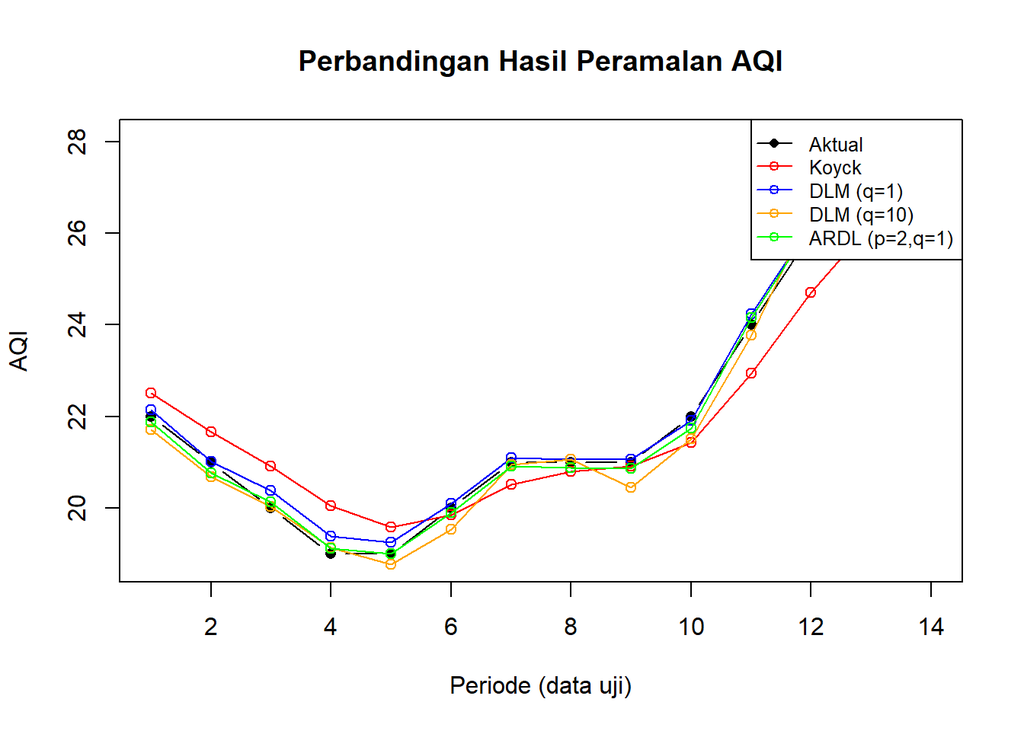

```r
par(mfrow = c(1, 1))

plot(1:nrow(test), test$Yt, type = "b", col = "black", pch = 16,
     xlab = "Periode (data uji)", ylab = "AQI",
     ylim = range(c(test$Yt, fore.koyck$forecasts, fore.dlm1$forecasts,
                    fore.dlm2$forecasts, fore.ardl$forecasts)),
     main = "Perbandingan Hasil Peramalan AQI")

points(1:nrow(test), fore.koyck$forecasts, col = "red");    lines(1:nrow(test), fore.koyck$forecasts, col = "red")
points(1:nrow(test), fore.dlm1$forecasts, col = "blue");    lines(1:nrow(test), fore.dlm1$forecasts, col = "blue")
points(1:nrow(test), fore.dlm2$forecasts, col = "orange");  lines(1:nrow(test), fore.dlm2$forecasts, col = "orange")
points(1:nrow(test), fore.ardl$forecasts, col = "green");   lines(1:nrow(test), fore.ardl$forecasts, col = "green")

legend("topright",
       c("Aktual", "Koyck", "DLM (q=1)", "DLM (q=10)", "ARDL (p=2,q=1)"),
       lty = 1, pch = c(16, 1, 1, 1, 1),
       col = c("black", "red", "blue", "orange", "green"), cex = 0.8)
```

Dari plot di atas, terlihat bahwa garis hasil peramalan model **ARDL** (hijau) dan **DLM q=1** (biru) paling mendekati garis data aktual (hitam) secara konsisten, sejalan dengan nilai MAPE yang mereka miliki. Model Koyck (merah) tampak sedikit lebih menyimpang dibanding model-model lain, meski secara umum seluruh model masih mampu menangkap tren pergerakan AQI dengan baik (MAPE seluruh model < 5%).

# 7 Kesimpulan

1. Lag optimum yang diperoleh: Koyck menggunakan struktur geometric lag (tidak memerlukan penentuan q secara eksplisit), DLM optimum pada **q = 10** (berdasarkan AIC), dan ARDL optimum pada **p = 2, q = 1** (berdasarkan AIC).
2. Berdasarkan metrik **MAPE data uji**, model **ARDL (p=2, q=1)** merupakan model terbaik untuk meramalkan AQI menggunakan O3 sebagai prediktor, karena memiliki MAPE terkecil dan visualisasi peramalan yang paling mendekati data aktual.